# Introduction to Mammalian Sequence Analysis

Author

Sergio Llaneza-Lago

# Setting up

## Bash terminal

#### Accessing Your Workshop Environment

1. **Follow [this link](https://github.com/UEA-Cancer-Genetics-Lab/MHC_RNA-seq_Workshop) to GitHub.**
2. **Log in to GitHub** if you are not already.
3. Find and click the green **`< > Code`** button.
4. In the pop-up window, select the **`Codespaces`** tab.
5. Click on **`Create codespace on main`**.
6. A new browser window will open and begin loading your terminal environment.

#### Setting Up Your Workspace

Once the Codespace has fully loaded and you see the terminal in the bottom pane:

1. Type the following command into the terminal:

```bash
bash download_reference.sh
```

2. Press enter.

## Script to install required libraries in Rstudio

1. Open Rstudio.
2. Copy and paste the following and run it:

```r
using <- function(...) {
  libs <- unlist(list(...))
  req <- unlist(lapply(libs, require, character.only = TRUE))
  need <- libs[!req]

  if (length(need) > 0) {
    # Install BiocManager if missing
    if (!requireNamespace("BiocManager", quietly = TRUE)) {
      install.packages("BiocManager")
    }

    # Try installing from CRAN first, then Bioconductor
    for (pkg in need) {
      tryCatch({
        install.packages(pkg)
      }, error = function(e) {
        message(paste("Trying Bioconductor for:", pkg))
        BiocManager::install(pkg, ask = FALSE)
      })
      library(pkg, character.only = TRUE)
    }
  }
}

# Load/install the required packages
using("tidyverse", "tximport", "DESeq2", "EnhancedVolcano", "gprofiler2")
```

# RNA-seq analysis

The goal of RNA-seq is often to perform differential expression testing to determine which genes or transcripts are expressed at different levels between conditions. These findings can offer biological insight into the processes affected by the condition(s) of interest. Below is an overview of the typical analysis workflow that is followed for differential gene expression analysis with bulk RNA-seq data.

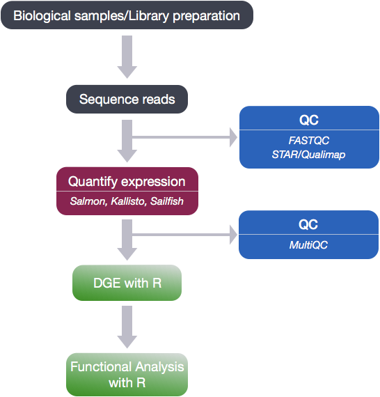

RNA-seq workflow and examples of software for each step.

This session is divided into two parts. In the first part, we will cover the process of transforming our RNA sequences into counts using a Bash terminal. During the second part, we will use R to identify differentially expressed genes and perform functional analysis.

## 1. How to use Bash?

### 1.1 Make a Folder

Use `mkdir` to make a folder (called a “directory”) to store your files.

```bash
mkdir rnaseq_project
```

### 1.2 Move Into That Folder

Use `cd` to change directory and go into it.

```bash
cd rnaseq_project
```

Use `cd ..` to go back one level.

### 1.3 See What’s Inside

Use `ls` to list files and folders.

```bash
ls
```

If you want more detail, try:

```bash
ls -l
```

### 1.4 Open compressed files

Use `zcat` to see the content of a file

```bash
zcat data/file.fq.gz
```

If the file is too big, you can combine `zcat` with `head` to get the first ten lines:

```bash
zcat data/file.fq.gz | head
```

## 2. From Sequence to Counts Using Bash

### 2.1 The FASTQ file

The first step in the RNA-Seq workflow is to take the FASTQ files received from the sequencing facility (e.g., Novogene) and assess the quality of the reads.

The FASTQ file format is the defacto file format for sequence reads generated from next-generation sequencing technologies. This file contains sequence data, but also contains quality information. For a single record (sequence read) there are four lines, each of which are described below:

| Line | Description |
| --- | --- |
| 1 | The header line. Always begins with ‘@’ and then shows information about the read |
| 2 | The actual DNA sequence |
| 3 | Always begins with a ‘+’ and sometimes repeats info from line 1 |
| 4 | String of characters which represent the quality scores; must have same number of characters as line 2 |

Let’s use the following read as an example:

```
@HWI-ST330:304:H045HADXX:1:1101:1111:61397
CACTTGTAAGGGCAGGCCCCCTTCACCCTCCCGCTCCTGGGGGANNNNNNNNNNANNNCGAGGCCCTGGGGTAGAGGGNNNNNNNNNNNNNNGATCTTGG
+
@?@DDDDDDHHH?GH:?FCBGGB@C?DBEGIIIIAEF;FCGGI#########################################################
```

As mentioned previously, line 4 has characters encoding the quality of each nucleotide in the read. The legend below provides the mapping of quality scores (Phred-33) to the quality encoding characters.

```
Quality encoding: !"#$%&'()*+,-./0123456789:;<=>?@ABCDEFGHI
                  |         |         |         |         |
   Quality score: 0........10........20........30........40
```

### 2.2 Assessing quality with FastQC

Now we understand what information is stored in a FASTQ file, the next step is to examine quality metrics for our data.

[FastQC](http://www.bioinformatics.babraham.ac.uk/projects/fastqc/) provides a simple way to do some quality control checks on raw sequence data coming from high throughput sequencing pipelines which you can use to give a quick impression of whether your data has any problems of which you should be aware before doing any further analysis.

#### 2.2.a Run FastQC

Below there is an example of how to use FastQC for paired reads from one sample:

```bash
fastqc mySample_2.fq.gz mySample_2.fq.gz -o outputDirectory/
```

FASTQ files are usually formatted as `fq` and are compressed into the `gzip` format (denoted as `gz`) to save space. FastQC can be applied directly to the compessed FASTQ files. The `-o` flag denotes where to store the output from the FastQC analysis.

#### 2.2.b Understanding FastQC results

Let’s take a closer look at the report that FastQC generates. One thing to keep in mind is that *FastQC is just an indicator of what’s going on with your data, don’t take the “PASS”es and “FAIL”s too seriously.*

FastQC has a really well documented [manual page](http://www.bioinformatics.babraham.ac.uk/projects/fastqc/) with [more details](http://www.bioinformatics.babraham.ac.uk/projects/fastqc/Help/) about all the plots in the report. We recommend looking at [this post](http://bioinfo-core.org/index.php/9th_Discussion-28_October_2010) for more information on what bad plots look like and what they mean for your data.

Below are two of the most important analysis modules in FastQC, the **“Per base sequence quality”** plot and the **“Overrepresented sequences”** table.

The **“Per base sequence quality”** plot provides the distribution of quality scores across all bases at each position in the reads.

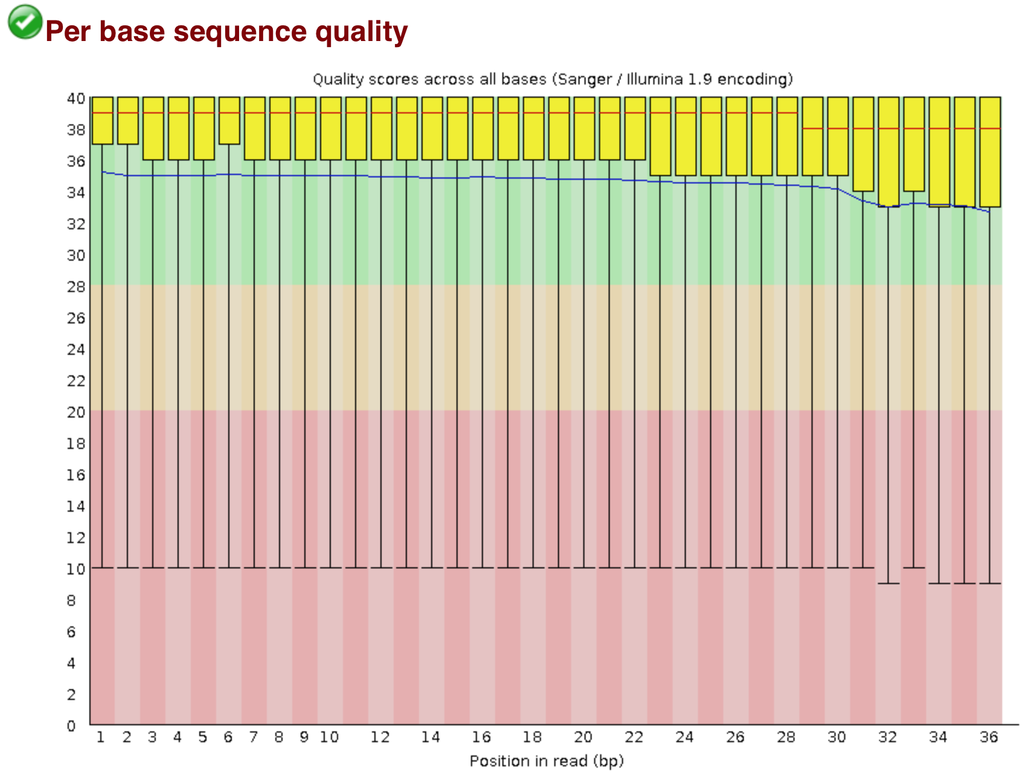

Sequence quality per base in a good quality sample.

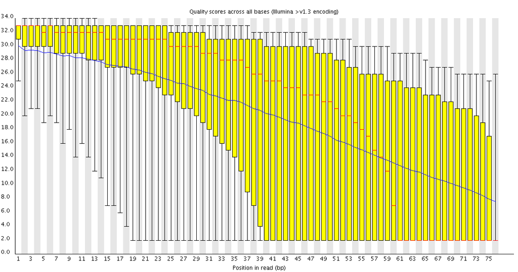

Sequence quality per base in a poor quality sample.

The **“Overrepresented sequences”** table displays the sequences (at least 20 bp) that occur in more than 0.1% of the total number of sequences. This table aids in identifying contamination, such as vector or adapter sequences.

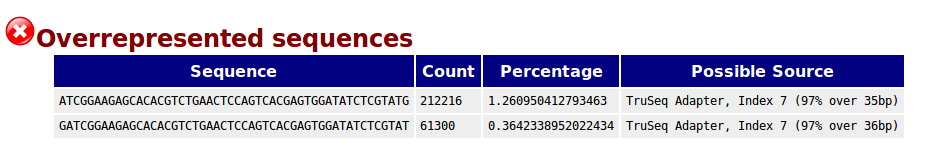

FastQC Overrepresented sequences example

### Exercises #1

1. For this first part of the session, we will use a paired-end chondrosarcoma sample located in `data/`. Examine the FASTQ files with `zcat`.
2. Perform FastQC on both reads of the sample and store the output in `results/fastqc/`.
3. Explore the FastQC report, are these good quality samples?

### 2.3 To count or to pseudocount?

Traditional RNA-seq pipelines follow a specific path: After quality control (QC), sequencing reads are trimmed to remove adapters and low-quality bases. These cleaned reads are then aligned base-by-base to a reference genome to pinpoint their original genomic locations.

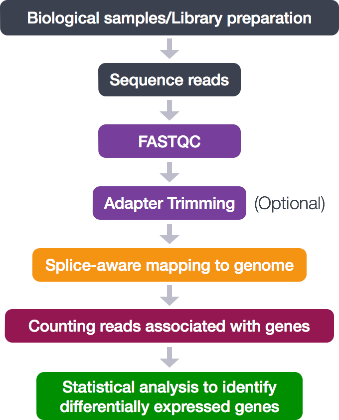

Standard RNA-seq workflow performing trimming and alignment

This alignment-based method is computationally demanding and takes a lot of time. **Another strategy for quantification which has more recently been introduced involves transcriptome mapping**. Tools that fall in this category include [Kallisto](https://pachterlab.github.io/kallisto/about), [Sailfish](http://www.nature.com/nbt/journal/v32/n5/full/nbt.2862.html) and [Salmon](https://combine-lab.github.io/salmon/); each working slightly different from one another.

Common to all of these tools is that **base-to-base alignment of the reads is avoided**, and these tools **provide quantification estimates much faster than do standard approaches** (typically more than 20 times faster) with **improvements in accuracy** at **the transcript level**. These transcript expression estimates, often referred to as ‘pseudocounts’, can be converted for use with DGE tools like DESeq2 or the estimates can be used directly for isoform-level differential expression using a tool like [Sleuth](http://www.biorxiv.org/content/biorxiv/early/2016/06/10/058164.full.pdf).

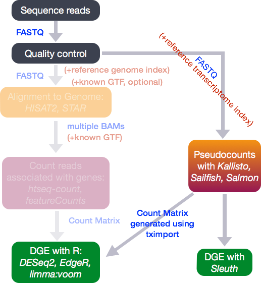

Aligment free alternative using Salmon and pseudocounts.

In this workshop we will explore Salmon in more detail.

### 2.4 What is Salmon?

[Salmon](http://salmon.readthedocs.io/en/latest/salmon.html#using-salmon) is a tool that takes a **reference transcriptome** (in FASTA format) and raw **sequencing reads** (in FASTQ format) as input. Unlike traditional methods, it does *not* align full reads. Instead, Salmon performs both mapping and quantification efficiently. It is known for being extremely fast at “mapping” reads to the transcriptome and often provides more accurate results than standard alignment-based approaches.

Let’s break down how Salmon works:

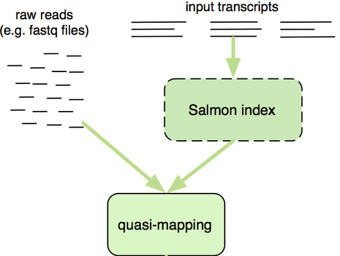

#### **2.4.a Indexing**

This step involves creating an index to evaluate the sequences for all possible unique sequences of length k (kmer) in the **transcriptome** (genes/transcripts).

#### **2.4.b Quasi-mapping and quantification**

The quasi-mapping approach estimates the numbers of reads mapping to each transcript, then generates final transcript abundance estimates after modeling sample-specific parameters and biases.

> **NOTE:** If there are sequences in the reads that are not in the index, they are not counted. As such, trimming is not required when using this method. Accordingly, if there are reads from transcripts not present in the reference transcriptome, they will not be quantified. Quantification of the reads is only as good as the quality of the reference transcriptome.

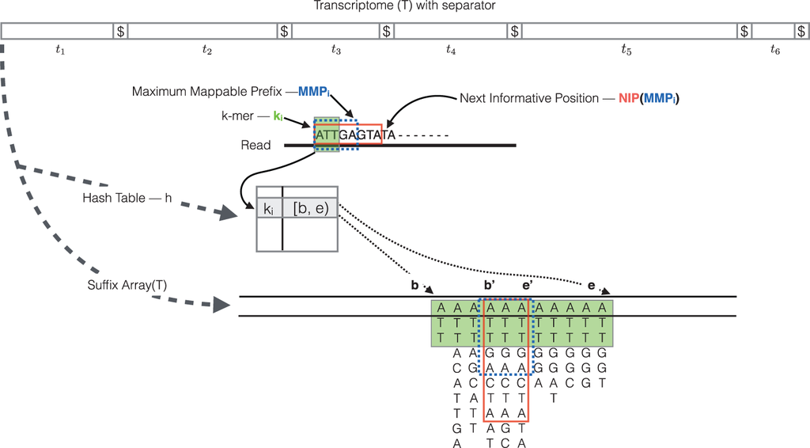

Salmon quasi-mapping process

### 2.5 Running Salmon

As you can imagine from the description above, when running Salmon there are also two steps.

**Step 1: Indexing** “Index” the transcriptome using the `index` command:

```bash
salmon index -t transcripts.fa -i transcripts_index --type quasi -k 31
```

> **NOTE:** Default for salmon is –type quasi and -k 31, so we do not need to include these parameters in the index command. The kmer default of 31 is optimized for 75bp or longer reads, so if your reads are shorter, you may want a smaller kmer to use with shorter reads (kmer size needs to be an odd number).

**We are not going to run this in class, but it only takes a few minutes.** We will be using an index we have generated from transcript sequences (all known transcripts/ splice isoforms with multiples for some genes) for human (GRCh37). The transcriptome data (FASTA) was obtained from the [GENCODE website.](https://www.gencodegenes.org/human/release_19.html)

**Step 2: Quantification:** Get the transcript abundance estimates using the `quant` command and the parameters described below (more information on parameters can be found [here](http://salmon.readthedocs.io/en/latest/salmon.html#id5)):

- **`-i`:** specify the location of the index directory (`reference_files/salmon_index/`)
- **`-l`:** library type (single-end reverse reads `SR`, but we can use `A` to automatically infer the library type) - more information is available [here](http://salmon.readthedocs.io/en/latest/salmon.html#what-s-this-libtype))
- **`-o`:** output quantification file name
- **`--writeMappings`:** instead of printing to screen, write to a file (`--writeMappings=salmon.out`)
- `-p`: Number of threads to use (how much computational power to dedicate for this task)

To run the quantification step on a single sample we have the command provided below.

```bash
salmon quant -i reference_files/salmon_index/ \
 -l A \
 -1 mySample_2.fq.gz \
 -2 mySample_2.fq.gz \
 -o results/salmonQuant \
 --writeMappings \
 --gcBias \
 -p 4
```

> **NOTE:** To correct for the various sample-specific biases you could add the following parameters to the Salmon command:
> - `--seqBias` will enable it to learn and correct for sequence-specific biases in the input data.
> - `--gcBias` to learn and correct for fragment-level GC biases in the input data
> - `--posBias` will enable modeling of a position-specific fragment start distribution

### Exercise #2

1. Perform `salmon quant` on the chondrosarcoma samples. Use the same arguments than the example when appropriate.
2. After Salmon finishes running, you should see a new directory created with the name you provided in the `-o` parameter. **Take a look inside this directory.**
3. Have you noticed the file named `quant.sf`? This is the primary quantification file. Each row in `quant.sf` corresponds to a transcript (identified by its Ensembl ID), and the columns list various quantification metrics for each transcript. **Explore this file to understand its contents.**

### 2.6 Salmon output

Salmon creates a directory containing a logs directory, which contains all of the text that was printed to screen as Salmon was running. Additionally, there is a file called `quant.sf`.

This is the **quantification file** in which each row corresponds to a transcript, listed by Ensembl ID, and the columns correspond to metrics for each transcript:

```bash
Name    Length  EffectiveLength TPM     NumReads
ENST00000632684.1       12      3.00168 0       0
ENST00000434970.2       9       2.81792 0       0
ENST00000448914.1       13      3.04008 0       0
ENST00000415118.1       8       2.72193 0       0
ENST00000631435.1       12      3.00168 0       0
ENST00000390567.1       20      3.18453 0       0
ENST00000439842.1       11      2.95387 0       0

....
```

- The first two columns are self-explanatory, the **name** of the transcript and the **length of the transcript** in base pairs (bp).
- The **effective length** represents the the various factors that effect the length of transcript due to technical limitations of the sequencing platform.
- Salmon outputs ‘pseudocounts’ which predict the relative abundance of different isoforms in the form of three possible metrics (KPKM, RPKM, and TPM). **TPM (transcripts per million)** is a commonly used normalization method and is computed based on the effective length of the transcript.
- Estimated **number of reads** (an estimate of the number of reads drawn from this transcript given the transcript’s relative abundance and length).

### Exercise #3

1. Download the `quant.sf` to your computer. We will not need to use the bash terminal anymore in this session, so feel free to close it.
2. In Rstudio, follow these steps:

```r
library(tximport)
library(tidyverse)

tx2knowngene <- read_csv("https://raw.githubusercontent.com/UEA-Cancer-Genetics-Lab/MHC_RNA-seq_Workshop/refs/heads/main/files_for_R/tx2knownGene.csv", col_select = c(2,3))

txi <- tximport("quant.sf",
                type = "salmon",
                tx2gene = tx2knowngene,
                ignoreTxVersion = TRUE)
```

> **NOTE:** Make sure that `quant.sf` is in your current working directory.
3. The previous command will import the quantification files and map it to genes. Which gene has the highest number of counts?

## 3. From Counts to Differential Expression and Enrichment

In this second part of the workshop, we will systematically walk through an RNA-seq differential expression workflow using various R packages.

Our starting point will be gene count data from both normal and tumor tissue samples derived from prostate cancer patients. We will then:

1. **Perform differential expression analysis** to identify genes that are significantly up- or down-regulated between the two conditions.
2. **Create a volcano plot** to visually represent our differentially expressed genes.
3. **Perform enrichment analysis** on our identified genes of interest to uncover their associated biological pathways or functions.
4. **Visualize our enrichment results** for better interpretation.

### 3.1 The Prostate Cancer (PRAD) dataset

We will be using publicly available prostate cancer expression data from **The Cancer Genome Atlas (TCGA)**. This dataset is included in the workshop repository and can be loaded directly into R.

#### Step 1: Load Expression Data

To load the gene expression data, run the following command in your R environment:

```r
pradExpression <- read_csv("https://raw.githubusercontent.com/UEA-Cancer-Genetics-Lab/MHC_RNA-seq_Workshop/refs/heads/main/files_for_R/PRAD_expression.csv")
```

This `pradExpression` dataset contains:

- **108 samples** (as columns).
- **20,828 genes** (as rows).
- Gene names are provided in the column named `SYMBOL`.

#### Step 2: Load Sample Information

In addition to the expression data, we also have detailed information about each sample. Download this by running:

```r
pradSampleInfo <- read_csv("https://raw.githubusercontent.com/UEA-Cancer-Genetics-Lab/MHC_RNA-seq_Workshop/refs/heads/main/files_for_R/PRAD_SampleInfo.csv")
```

This `pradSampleInfo` dataset contains:

- **108 rows**, with each row representing a unique sample.
- **Three columns:**
  - `PatientID`: A unique identifier for each patient.
  - `SampleID`: A unique identifier for each sample.
  - `SampleType`: Indicates if the sample is from **tumoural** tissue (denoted as ‘Tumour’) or **normal** tissue.

You will observe that for all patients, we have paired samples: one normal and one tumoural.

### 3.2 Differential expression analysis with DESeq2

**DESeq2** is a widely used R package for gene-level differential expression analysis. It employs the negative binomial distribution and is known for balancing sensitivity and specificity, helping to reduce both false positives and false negatives in your results. For more details and helpful tips, refer to the [DESeq2 vignette](http://bioconductor.org/packages/devel/bioc/vignettes/DESeq2/inst/doc/DESeq2.html).

#### 3.2.a DESeq2 input

We can use the function *`DESeqDataSetFromMatrix`* for our already prepared read count matrix. For this, we require three inputs:

1. A **count matrix** (as an R `matrix` object).
2. A **sample information data frame** (where rows correspond to samples and columns contain metadata).
3. A **design formula**.

**Important:** The row names of your sample information data frame *must exactly match* the column names of your count matrix.

A design formula tells the statistical software which sources of variation to test for. This includes your primary factor of interest (e.g., treatment vs. control) and any other known covariates that contribute significantly to variation in your data (e.g., sex, age, batch effects). **The design formula should have all of the factors in your metadata that account for major sources of variation in your data.**

For example, suppose we have the following sample info:

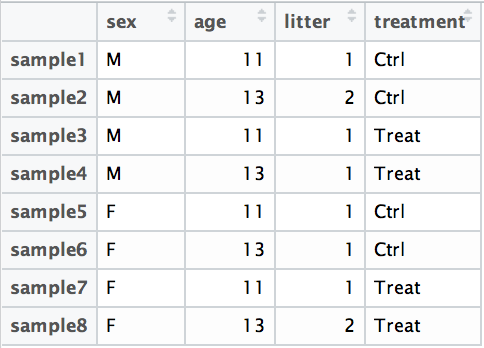

If you want to examine the expression differences between treatments, your design formula would be:

`design = ~ treatment`

However, if you know that `sex` and `age` are also major sources of variation, your formula should include them to account for their effects:

`design = ~ sex + age + treatment`

The tilde (`~`) should always precede your factors and tells DESeq2 to model the counts using the following formula. Note the **factors included in the design formula need to match the column names in the metadata**.

#### 3.2.b Preparing our data

Currently, both our `pradExpression` (counts) and `pradSampleInfo` (sample information) are data frames, and neither has appropriate row names for DESeq2. Let’s fix this.

##### Exercise # 4

1. Complete and run the following code:

   ```r
   expressionMatrix <- [Type here your count matrix file] |>
     column_to_rownames([Type here the column to convert into row names, use quotation marks]) |>
     as.matrix()
   ```

2. Modify `pradSampleInfo` so the column `SampleID` becomes the row names. Keep it as a data frame.
3. All data is ready, time to create our `DESeq2` object. Complete and run the following code using the sample type as design:

```r
library(DESeq2)

dds <- DESeqDataSetFromMatrix(countData = [Type here your count matrix],
                              colData = [Type here your sample info dataframe],
                              design = ~ [Add here the factor to compare by])
```

#### 3.2.c Running DESeq2

In the previous section, we created a `DESeq2` object in our R environment. To run the analysis just run this code:

```r
des <- DESeq(dds)
```

`DESeq2` will start to analyse your data and print the progress to your console. You’ll notice that the analysis performs several steps. We will be taking a detailed look at each of these steps to better understand how DESeq2 is performing the statistical analysis and what metrics we should examine to explore the quality of our analysis.

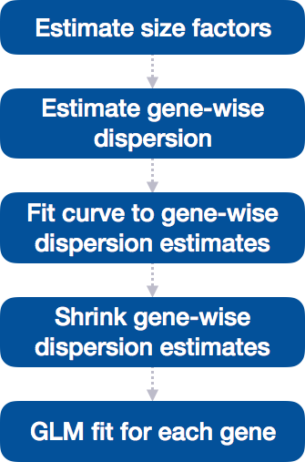

##### Step 1: Estimate size factors

The first step in the differential expression analysis is to estimate the size factors. In RNA-seq experiments, the raw counts we obtained depend on how much the gene is expressed and how much sequencing was done. This means that some samples may have more reads purely for technical reasons, not because of biological differences.

To correct this, DESeq2 calculates a size factor for each sample to adjust for differences in sequencing depth and scales them accordingly. This way we can ensure that we compare biologically meaningful differences.

In the example below, imagine the sequencing depths are similar between Sample A and Sample B, and every gene except for gene DE presents similar expression level between samples. The counts in Sample B would be greatly skewed by the DE gene, which takes up most of the counts. Other genes for Sample B would therefore appear to be less expressed than those same genes in Sample A.

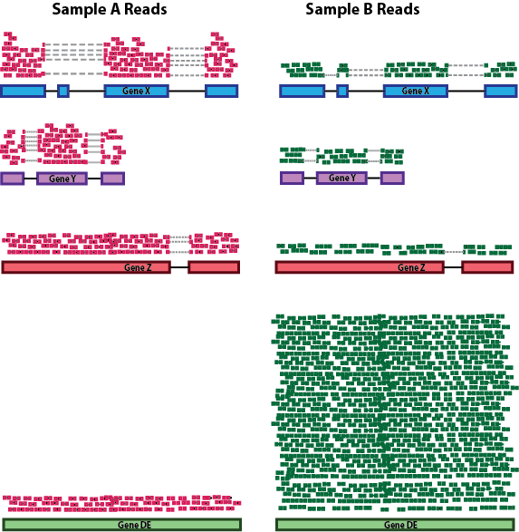

##### Step 2: Estimate gene-wise dispersion

Next, DESeq2 estimates the dispersion for each gene. Dispersion measures how much a gene’s expression varies between replicates, after correcting for sequencing depth.

A gene with stable counts across samples has low dispersion. A gene with more fluctuation has high dispersion. This information is used to decide how much confidence to place in any differences observed between groups.

For example, if we imagine two genes:

- Gene A: Counts are always around 100 across samples. It has low dispersion.
- Gene B: Sometimes the counts are 10, sometimes is 500. It has high dispersion.

Even if both genes have similar average counts, Gene B is less consistent and needs stronger evidence to be considered significantly differentially expressed.

##### Step 3: Fit curve to gene-wise dispersion estimates

The next step in the workflow is to fit a curve to the gene-wise dispersion estimates. The idea here is that when dispersion is plotted against mean expression for all genes, a clear trend usually appears: genes with lower expression tend to show higher variability.

DESeq2 fits a smooth curve through these points to model this relationship. The curve reflects the expected dispersion for a gene based on its average expression level.

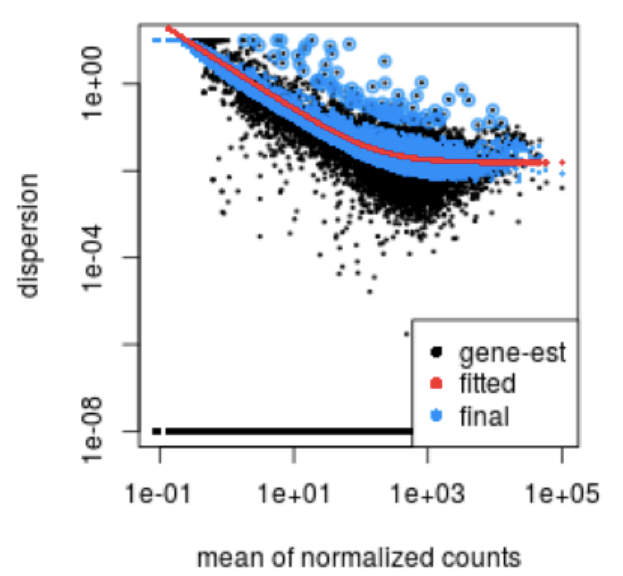

In this plot we have dispersion on the y-axis and mean normalized counts on the x-axis. Each black dot represents a gene. Simply looking at the trend of black dots, we observe an inverse relationship between mean and dispersion.

##### Step 4: Shrink gene-wise dispersion estimates toward the values predicted by the curve

The raw dispersion estimates, especially for lowly expressed genes, are often unreliable. DESeq2 applies a method called shrinkage, which adjusts these estimates towards the fitted curve.

This improves the accuracy of the analysis. Noisy or extreme values are moderated, while more stable genes remain largely unaffected. The extent of shrinkage depends on how far a gene’s dispersion is from the expected trend and how many samples are in the dataset.

Shrinkage is important for reducing false positives, particularly when working with small sample sizes.

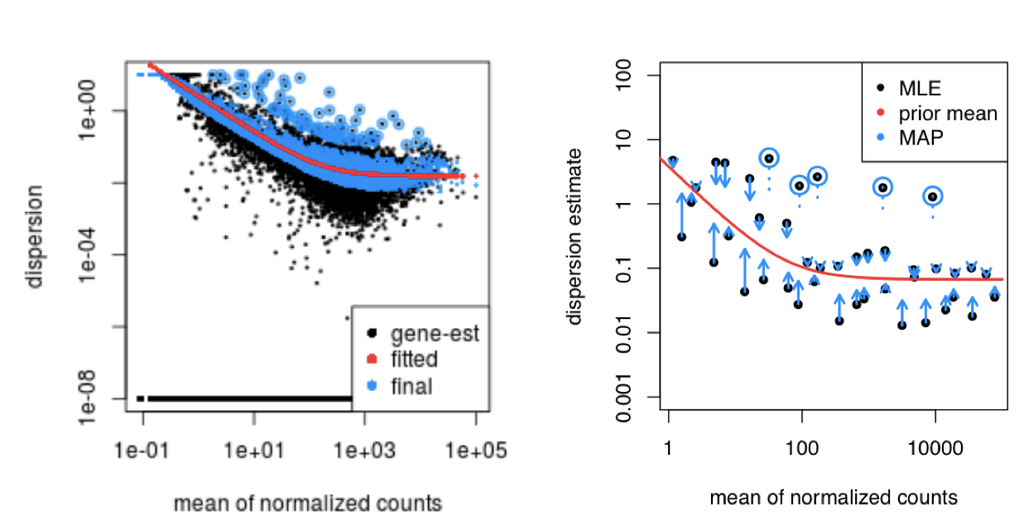

Example of genes (black dots) being pulled to the curve. Genes with a dispersion very away from the curve are not pulled as they are assumed that their values hold biological value.

##### Step 5: Comparing groups

Once dispersions have been adjusted, DESeq2 compares gene expression between groups.

- If comparing two groups (e.g. High vs Low risk), DESeq2 uses the Wald test.
- If comparing more than two groups, it uses the Likelihood Ratio Test (LRT).

Each gene is assigned a p-value. However, when testing thousands of genes, some may appear significant by chance. This is known as the multiple testing problem.

DESeq2 corrects for this by adjusting the p-values using the False Discovery Rate (FDR), based on the Benjamini-Hochberg method. By default, it uses a threshold of 0.05. This means that among the genes called significant, no more than 5% are expected to be false positives.

For instance, if 500 genes are declared differentially expressed at FDR < 0.05, we expect around 25 of those to be false positives.

#### 3.2.c. DESeq2 results

After running the DESeq2 analysis, we’ll use the `results()` function to extract the outcomes.

Run the following command to get your differential expression results:

```r
deResults <- as.data.frame(results(des, name = "SampleType_Tumour_vs_Normal")) |>
  rownames_to_column('SYMBOL')
```

> **Note on `name` parameter:** In this analysis, we are only comparing two groups (`Tumour` vs. `Normal` within `SampleType`), so DESeq2 will by default return this specific comparison. Therefore, explicitly setting `name = "SampleType_Tumour_vs_Normal"` is good practice for clarity, but not strictly necessary here. However, if you were comparing three or more groups, or if your design included additional cofactors, you **would need to specify** which comparison you want to extract.

This command will produce a data frame named `deResults`, where each row corresponds to one of the genes we tested for differential expression. The columns provide key metrics for each gene:

- **`baseMean`**: The average of the normalised count values, taken over all samples. This represents the gene’s overall expression level.
- **`log2FoldChange`**: This value indicates the magnitude and direction of expression change.
  - A **positive** `log2FoldChange` means the gene is overexpressed (up-regulated) in tumour samples compared to normal samples.
  - A **negative** `log2FoldChange` means the gene is underexpressed (down-regulated) in tumour samples compared to normal samples.
  - **Interpretation:** A `log2FoldChange` of 1 means the gene is 2 times more expressed. A value of 2 means it’s 4 times more expressed, and so on.
- **`lfcSE`**: The standard error of the `log2FoldChange` estimate.
- **`stat`**: The Wald test statistic, which is the `log2FoldChange` divided by its `lfcSE`.
- **`pvalue`**: The p-value obtained from the Wald test, indicating the probability of observing such a `log2FoldChange` by chance if there were no true difference.
- **`padj`**: The adjusted p-value (using the Benjamini-Hochberg (BH) method).

### Exercise #5

1. Plot the gene-wise dispersion curve by running:

   ```r
   plotDsipEsts(des)
   ```

   Does the dispersion follow the curve?
2. Create a new data frame containing only the significantly differentially expressed genes. This can be done by **filtering** in the genes in `deResults` with `padj < 0.05`.
3. Find the 5 genes significantly more overexpressed and the five more underexpressed. Search a couple on Google to find what is their role in prostate cancer. Do they make biological sense?

### 3.3 Visualising our DESeq2 output with `EnhancedVolcano`

When we are working with large amounts of data it can be useful to display that information graphically to gain more insight. Visualization deserves an entire course of its own, but during this lesson we will get you started with volcano plots.

Volcano plots show the log transformed adjusted p-values plotted on the y-axis and log2 fold change values on the x-axis. They are useful because they give an overall distribution of the expression of our genes. There is no built-in function for the volcano plot in DESeq2, so instead we will use the `EnhancedVolcano` package. This package uses `ggplot2` as a base to create the plots so it allows for a lot of customisation, more information can be [found here](https://bioconductor.org/packages/devel/bioc/vignettes/EnhancedVolcano/inst/doc/EnhancedVolcano.html).

It can be used this way:

```r
library(EnhancedVolcano)

EnhancedVolcano([Add here the results dataframe we got from DEseq2],
                lab = [Column from the results containing gene names as results$geneNames],
                x = [Name of the column from the results containing the fold change values, needs to be within quotation marks, e.g. 'fold'],
                y = [Name of the column from the results containing the adjusted p-values, needs to be within quotation marks],
                title = 'PRAD Tumour vs Normal',
                pCutoff = 0.05,
                FCcutoff = 1,
                drawConnectors = TRUE,
                widthConnectors = 0.75,
                pointSize = 1.5,
                labSize = 3.0)
```

### Exercise #6

Use `EnhancedVolcano` to visualise your differentially expressed genes.

### 3.4 Functional enrichment analysis with `gProfiler2`

The output of RNA-seq differential expression analysis is a list of significant differentially expressed genes (DEGs). To gain greater biological insight on the differentially expressed genes there are various analyses that can be done:

- determine whether there is enrichment of known biological functions, interactions, or pathways
- identify genes’ involvement in novel pathways or networks by grouping genes together based on similar trends
- use global changes in gene expression by visualizing all genes being significantly up- or down-regulated in the context of external interaction data

Generally for any differential expression analysis, it is useful to interpret the resulting gene lists using freely available web-and R-based tools. In this session, we will use the R package `gProfiler2` to perform functional enrichment through the Gene Ontology (GO) database, the Kyoto Encyclopedia of Genes and Genomes (KEGG) database, and the Reactome Pathway Database.

*Note that all tools described below are great tools to validate experimental results and to make hypotheses. These tools suggest genes/pathways that may be involved with your condition of interest; however, you should NOT use these tools to make conclusions about the pathways involved in your experimental process. You will need to perform experimental validation of any suggested pathways.*

#### 3.4.a How does Functional Enrichment work?

These three databases (KEGG, GO, and Reactome) categorise genes into groups (gene sets) based on a shared function, or involvement in a pathway, or presence in a specific cellular location, or other categorisations such as functional pathways.

For each gene set, `gProfiler2` calculates the probability that the observed number of your significantly differentially expressed genes within that set is higher than expected by chance. This calculation compares your gene list to a “background” set (in our case, the entire human transcriptome). The statistical significance of this over-representation is determined using the **hypergeometric test**.

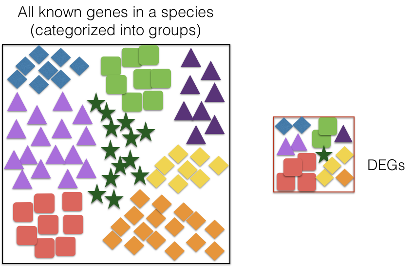

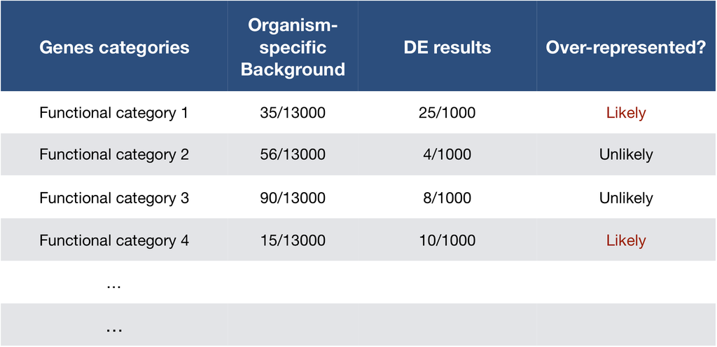

Each of the three databases you will use today have their own system to categorise genes.

- GO is helpful for understanding the biological processes that genes/products are involved in. It is subdivided into three ‘ontologies’:
  - Biological processes (BP): refers to the biological role involving the gene or gene product, and could include “transcription”, “signal transduction”, and “apoptosis”.
  - Cellular component (CC): refers to the location in the cell of the gene product. Cellular components could include “nucleus”, “lysosome”, and “plasma membrane”.
  - Molecular function (MF): represents the biochemical activity of the gene product, such activities could include “ligand”, “GTPase”, and “transporter”.
- KEGG is more appropriate for understanding the precise pathway where the gene/product is active. It also contains various biological systems and diseases but requires licensing for certain access.
- Reactome is a manually curated database primarily focused on human biological processes. It is completely open-source and contains cross-links to other databases.

#### 3.4.b How to use `gprofiler2`?

To use `gprofiler2`, the first step is to query for gene sets associated with your differentially expressed genes. It’s a good practice to separate your genes into overexpressed and underexpressed lists, as this makes interpreting the enrichment results much easier.

Additionally, while optional, providing your genes ranked from most to least differentially expressed (`log2FoldChange`) significantly improves the accuracy and biological relevance of the enrichment results. More details about `gprofiler2` can be found in its [documentation](https://cran.r-project.org/web/packages/gprofiler2/vignettes/gprofiler2.html).

Here’s an example of how to perform a `gprofiler2` query:

```r
library(gprofiler2)

gostres <- gost(query = deResults$SYMBOL,
                   organism = "hsapiens",
                   significant = TRUE,
                   sources = c("REAC", "KEGG", "GO:BP"),
                   correction_method = "fdr",
                   ordered_query = TRUE)
```

Let’s break down the parameters used in this `gost()` function:

- **`query`**: This is your list of gene identifiers (e.g., gene symbols). For best results, this list should be sorted by a measure of differential expression, such as `log2FoldChange` (from most to least differentially expressed).
- **`organism`**: Specifies the organism being analysed. For human, use `"hsapiens"`.
- **`significant`**: If set to `TRUE`, only significant enrichment results (based on the adjusted p-value threshold) will be returned.
- **`sources`**: A character vector indicating which databases to query. For this session, we will use:
  - `"REAC"` for Reactome pathways.
  - `"KEGG"` for KEGG pathways.
  - `"GO:BP"` for Gene Ontology Biological Process terms.
- **`correction_method`**: Defines the method used to adjust the p-values obtained from the hypergeometric test for multiple testing. `"fdr"` (False Discovery Rate) is a common and robust choice.
- **`ordered_query`**: Set to `TRUE` if your `query` gene list is sorted (e.g., by `log2FoldChange`). This allows `gprofiler2` to perform a more sensitive and specific ranked enrichment analysis.

You can access the full results of your query by inspecting the `gostres$results` object:

```r
gostres$results
```

#### 3.4.c Visualising `gprofiler2` results

We can use the function `gostplot` to visualise all our enrichment results in a Manhattan plot by running this:

```r
gostplot(gostres, capped = TRUE, interactive = TRUE)
```

> **NOTE:** You will need to set `interactive` to `FALSE` if you want to edit this plot in the future.

[figure not shown]

Manhattan plot generated by `gostplot`. Each circle corresponds to a significantly enriched gene set. The y-axis denotes how much enriched they are. In this image, one biological process is higlighted by clicking on it.

It is possible to pick specific gene sets to highlight on the plot using the function `publish_gostplot`. Here is an example highlighting sets that we found related to muscle contraction:

[figure not shown]

Manhattan plot highlighting the selected gene sets. At the bottom, it includes a table with the selected gene sets, the number of genes included in the set (term_size) and the p-value from the geometric test.

```r
gplot <- gostplot(gostres, capped = TRUE, interactive = FALSE)

publish_gostplot(gplot,
                 highlight_terms = c("KEGG:04260", "REAC:R-HSA-390522", "REAC:R-HSA-397014"))
```

##### Visualising using `ggplot2`

Another alternative is to create our own plots using the `ggplot2` package. A common way to represent gene sets is using barplots, for example:

```r
ggplot(gostres$result, aes(x = intersection_size, y = reorder(term_name, intersection_size), fill = p_value)) +
  geom_bar(stat = 'identity') +
  scale_fill_gradient(low = "blue", high = "red")
```

> **NOTE:** The `reorder` function ensures that the bars are sorted from higher to smaller. It is optional but it makes the plot to look much better.

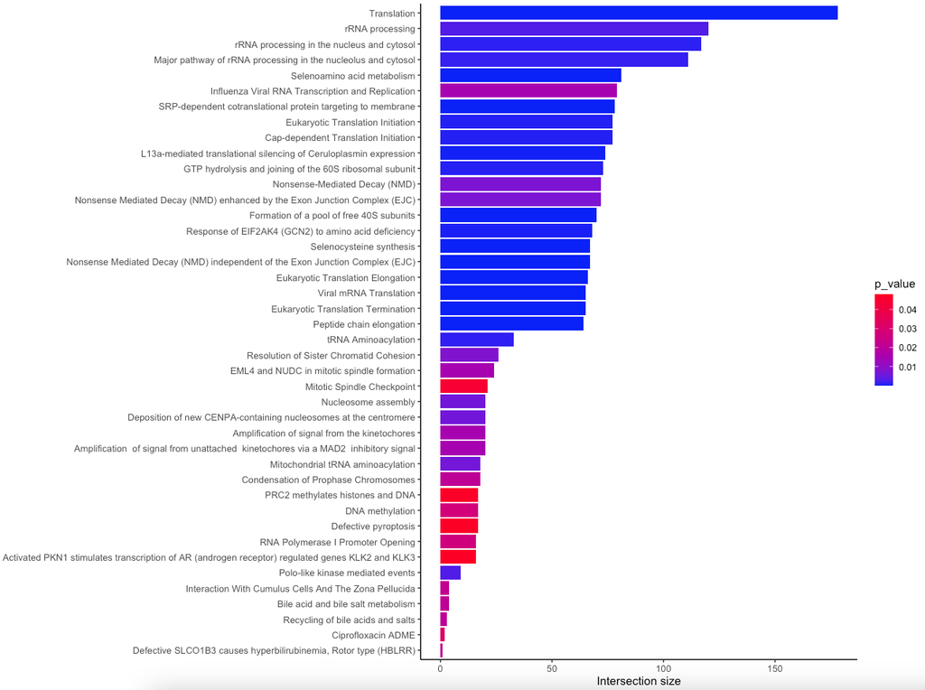

### Exercise #7

1. Create two new data frames, one containing only the significant upregulated genes from `deResult` and another only the significant downregulated genes. Sort them by the log2 Fold Change.
2. Use the `gost` function on both sets of data, and explore the outcome.
3. Use `gostplot` to visualise your enrichment results.
4. Use `publish_gostplot` and highlight the ten upregulated Reactome pathways with the biggest `intersection_size`.
5. Using `ggplot2` create a barplot of the upregulated Reactome pathways.
6. Using your previous barplot as a starting point:
   - Change the barplot to a scatterplot.
   - Make the dots on the scatterplot to be coloured by the `p_value`.
   - Make the size of the dots at the scatterplot to be dependant on the `intersection_size`.

*Part of the material of this workshop was adapted from Dr Sarah Boswell from Laboratory of Systems Pharmacology, Single Cell Core; and Dr Radhika Khetani ,Training Director at the Harvard Chan Bioinformatics Core RNA-seq workshop available at https://hbctraining.github.io/rnaseq-cb321/.*